# Lecture 10.1 Decision trees

EBA3501 Foundations of Data Science

Jan Ditzen

2026-11-03

## Decision trees

- We describe tree-based methods for regression and classification.
- These involve *segmenting* the predictor space into a number of simple regions.
- We have already done this with step functions, but decision trees go a step further.
- The set of splitting rules used to segment the predictor space can be summarized in a *tree*. These types of approaches are known as *decision-tree* methods.

## Pros and cons

- Tree-based methods are simple and useful for interpretation.
- However they typically are not competitive with the best supervised learning approaches in terms of predictive performance.
- Hence we also discuss bagging, random forests, and boosting. (Later!)
- These methods grow multiple trees which are then combined to yield a single consensus prediction.
- Combining a large number of trees can often result in dramatic improvements in prediction accuracy, at the expense of some loss interpretation.

## Basics

- Decision trees can be use for both regression and classification.
- We first consider regression problems, then classification.

## What is a tree?

A tree is a directed acyclic graph.

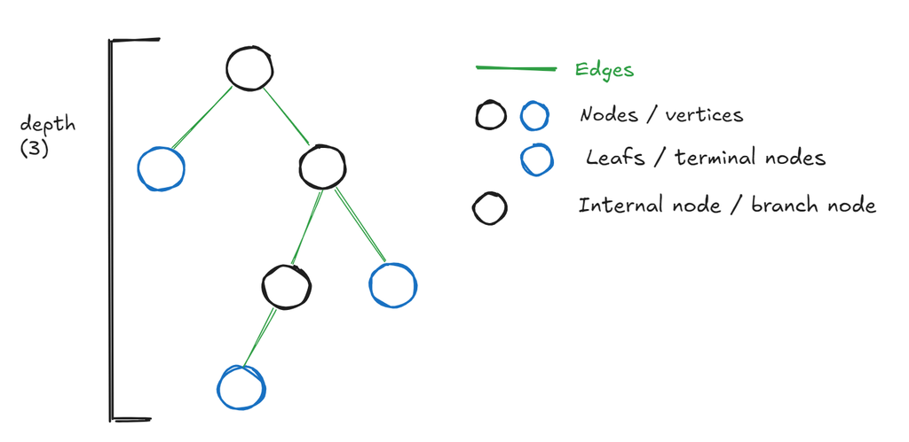

## Baseball log-salary

- Data
- Data prep
- Plot
- Splitting

> [Major League Baseball Data](https://islp.readthedocs.io/en/latest/datasets/Hitters.html) from the 1986 and 1987 seasons.

```python
from ISLP import load_data
Hitters = load_data('Hitters')
Hitters.head()
```

|  | AtBat | Hits | HmRun | Runs | RBI | Walks | Years | CAtBat | CHits | CHmRun | CRuns | CRBI | CWalks | League | Division | PutOuts | Assists | Errors | Salary | NewLeague |
| --- | --- | --- | --- | --- | --- | --- | --- | --- | --- | --- | --- | --- | --- | --- | --- | --- | --- | --- | --- | --- |
| 0 | 293 | 66 | 1 | 30 | 29 | 14 | 1 | 293 | 66 | 1 | 30 | 29 | 14 | A | E | 446 | 33 | 20 | NaN | A |
| 1 | 315 | 81 | 7 | 24 | 38 | 39 | 14 | 3449 | 835 | 69 | 321 | 414 | 375 | N | W | 632 | 43 | 10 | 475.0 | N |
| 2 | 479 | 130 | 18 | 66 | 72 | 76 | 3 | 1624 | 457 | 63 | 224 | 266 | 263 | A | W | 880 | 82 | 14 | 480.0 | A |
| 3 | 496 | 141 | 20 | 65 | 78 | 37 | 11 | 5628 | 1575 | 225 | 828 | 838 | 354 | N | E | 200 | 11 | 3 | 500.0 | N |
| 4 | 321 | 87 | 10 | 39 | 42 | 30 | 2 | 396 | 101 | 12 | 48 | 46 | 33 | N | E | 805 | 40 | 4 | 91.5 | N |

```python
from ISLP import load_data
Hitters = load_data('Hitters')
Hitters["LogSalary"] = np.log(Hitters["Salary"])
Hitters = Hitters.dropna()

X = Hitters[["Years", "Hits"]]
y = Hitters["LogSalary"]
Hitters.shape
```

```
(263, 21)
```

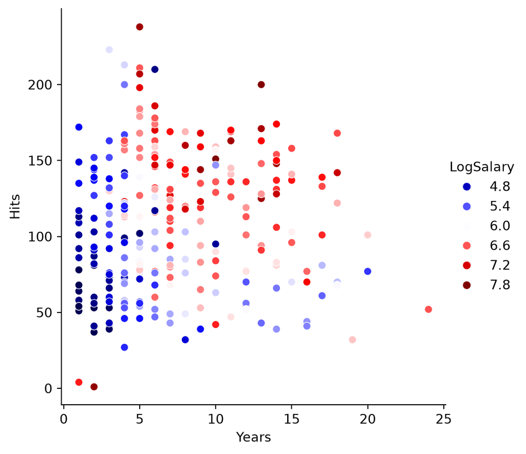

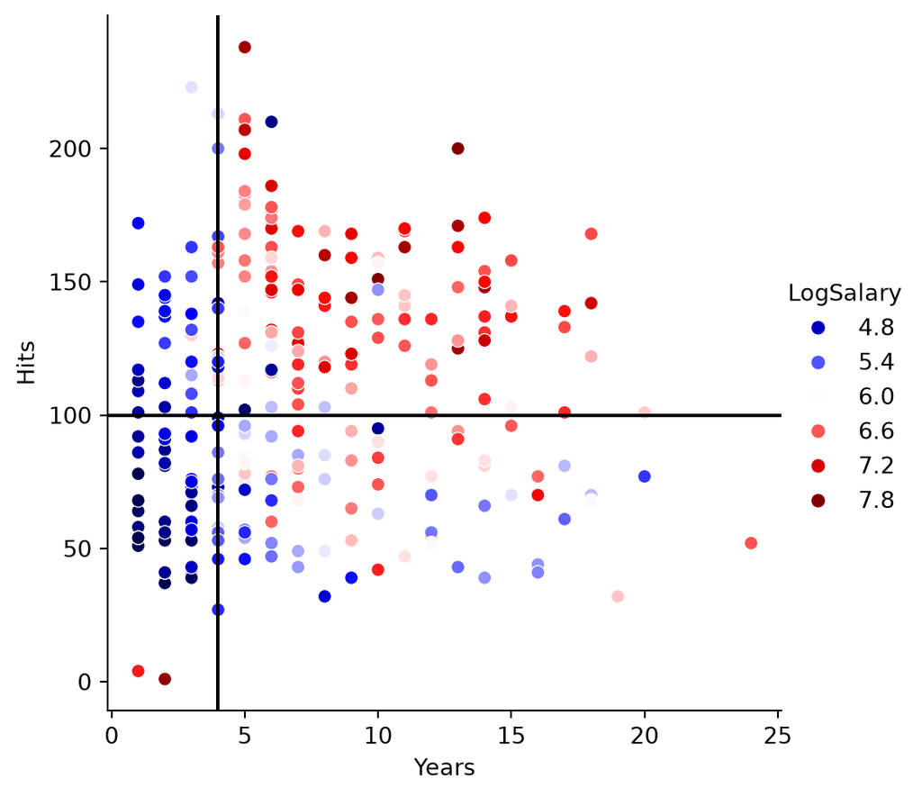

```python
sns.relplot(Hitters, x="Years", y = "Hits", hue = "LogSalary", palette = "seismic")
plt.axhline(100, color = "black")
plt.axvline(4, color = "black")
```

## A decision tree

- Fit tree
- Tree structure
- Plotting

```python
from sklearn.tree import DecisionTreeRegressor
regressor_2_depth = DecisionTreeRegressor(random_state=0, max_depth = 2).fit(X,y)
regressor_2_depth
```

```
DecisionTreeRegressor(max_depth=2, random_state=0)
```

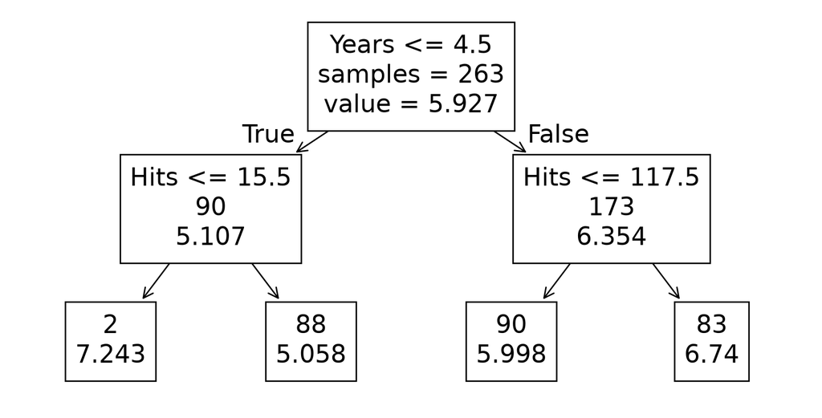

```python
from sklearn.tree import plot_tree

plot_tree(regressor_2_depth, feature_names=["Years", "Hits"], impurity=False, label="root")
pass
```

1. How many internal nodes does the tree have?
2. How many leaf nodes are there?

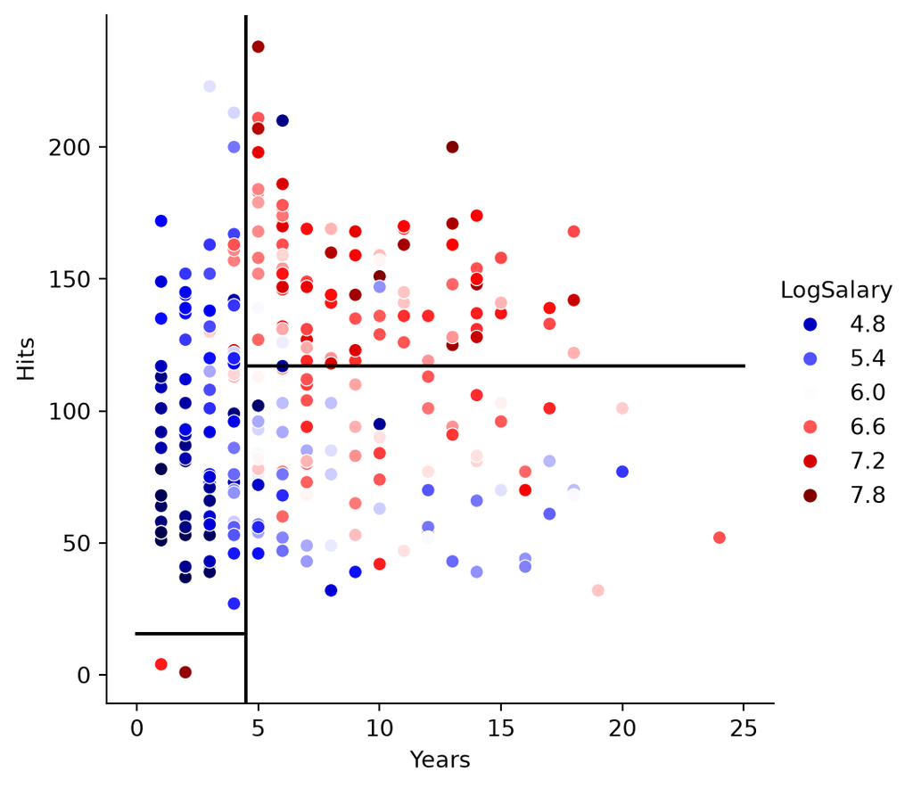

```python
sns.relplot(Hitters, x="Years", y = "Hits", hue = "LogSalary", palette = "seismic")
plt.axvline(4.5, color = "black")
plt.plot((0,4.5), (15.5, 15.5), color = "black")
plt.plot((4.5, 25), (117, 117), color = "black")
```

## Interpretation

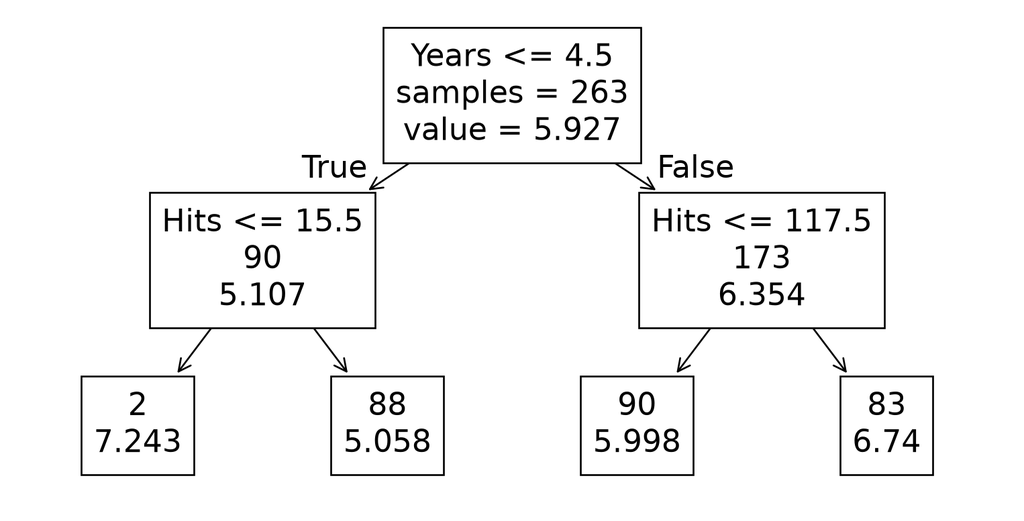

- `Years` is the most important factor in determining `LogSalary`. Players with less experience earn lower salaries than more experienced players.
- Given that a player is less experienced, the number of `Hits` play little role in his Salary, with two outliers.
- Among players who have been in the major leagues for 4.5 or more years, the number of Hits made in the previous year does affect Salary, and players who made more Hits last year tend to have higher salaries.

## Fundamental idea of decision trees

1. We divide the predictor space — that is, the set of possible values for $X_1,X_2,...,X_p$ — into $J$ distinct and non-overlapping rectangles, $R_1,R_2,...,R_J$.
2. For every observation that falls into the rectangle $R_j$ its predicted value is equal to the mean over all traning values in $R_j$.

**This is a multidimensional version of step-functions!**

The goal is to find the rectangles $R_1,...,R_J$ that minimize the mean squared error,
$$\sum_{m=1}^{J} \sum_{x_i\in R_m} (y_i− \hat{y}_{R_m})^2$$

$\hat{y}_{R_m}$ is the mean of the training observations in $R_m$.

## Trees, not histograms

- It is computationally expensive to go through every possible partition of the feature space into $J$ boxes.
- Indeed, this problem is $NP$-complete, and is sometimes called regression histograms.
- But this would, in any case, lead to *overfitting*.
- For this reason, we take a *top-down*, *greedy* approach that is known as *recursive binary splitting*.
- The approach is *top-down* because it begins at the top of a tree and then successively splits the predictor space; each split is indicated via two new branches further down on the tree.
- It is *greedy* because at each step of the tree-building process, the best split is made at that particular step, rather than looking ahead and picking a split that will lead to a better tree in some future step.

## The algorithm

1. We first select the predictor $X_j$ and the cutpoint $s$ such that splitting the predictor space into the regions ${X|X_j < s}$ and ${X|X_j ≥ s}$ leads to the greatest possible reduction in mean squared error.
2. We repeat the process, looking for the best predictor and best cutpoint in order to split the data further so as to minimize the mean squared error within each of the resulting regions.
3. But instead of splitting the entire predictor space, we split one of the two previously identified regions. We now have *three regions*.
4. Again, we look to split one of these three regions further to minimize the mean squared error. The process continues until a *stopping criterion* is reached. For instance, we may continue until no region contains more than five observations.

## Parameters in `sklearn`

The `DecisionTreeRegressor` takes *many* parameters.

- Parameters
- Defaults
- Implied tree
- Tree properties
- `max_depth`: The maximal number of splits along any path from the root to a leaf.
- `min_samples_split`: The minimal number of samples in a region for it to be a candidate for splitting.
- `min_samples_leaf`: The minimal number of samples in a leaf node.
- `max_leaf_nodes`: The maximal number of leafs in the tree.
- `max_features`: How many features to try in a split? The features are chosen at random.

The default values in `sklearn` are not very restrictive - we’ll soon see why.

```python
regressor = DecisionTreeRegressor(random_state=0).fit(X,y)
regressor.get_params()
```

```
{'ccp_alpha': 0.0,
 'criterion': 'squared_error',
 'max_depth': None,
 'max_features': None,
 'max_leaf_nodes': None,
 'min_impurity_decrease': 0.0,
 'min_samples_leaf': 1,
 'min_samples_split': 2,
 'min_weight_fraction_leaf': 0.0,
 'monotonic_cst': None,
 'random_state': 0,
 'splitter': 'best'}
```

The fitted tree is massively overfitted.

[output not shown]

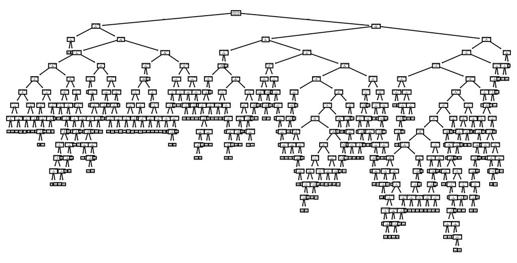

```python
plot_tree(regressor, impurity=False, label="root")
```

The tree is very deep

```python
regressor.get_depth()
```

```
18
```

And has obscenely many leafs, almost one for each observation.

```python
regressor.get_n_leaves()
```

```
np.int64(248)
```

Compare to the number of observations in the data set

```python
Hitters.shape
```

```
(263, 21)
```

## Changing parameters

Two interesting parameters are `max_leaf_nodes` and `max_depth`.

- `max_depth`
- `max_leaf_nodes`
- Cross-validation

Let’s try a maximal depth of 3:

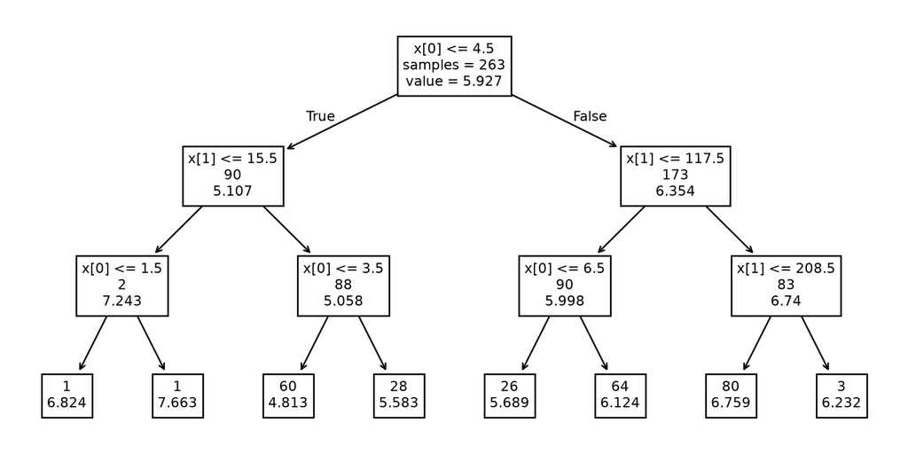

```python
regressor_3_depth = DecisionTreeRegressor(random_state=0, max_depth = 3).fit(X,y)
plot_tree(regressor_3_depth, impurity=False, label="root")
pass
```

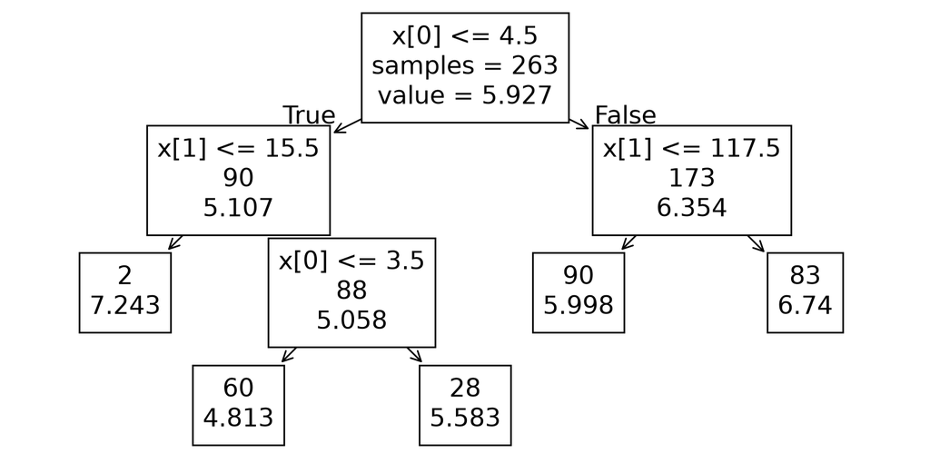

```python
regressor_5_leafs = DecisionTreeRegressor(random_state=0, max_leaf_nodes = 5).fit(X,y)
plot_tree(regressor_5_leafs, impurity=False, label="root")
pass
```

We inspect the models using cross-validation:

```python
from sklearn.model_selection import cross_val_score
cvs = {"3_depth": cross_val_score(regressor_3_depth, X, y, cv = 10).mean(),
 "5_leafs": cross_val_score(regressor_5_leafs, X, y, cv = 10).mean(),
 "2_depth": cross_val_score(regressor_2_depth, X, y, cv = 10).mean()}
cvs
```

```
{'3_depth': np.float64(0.5027641922407687),
 '5_leafs': np.float64(0.5484981677758443),
 '2_depth': np.float64(0.4930136953220773)}
```

The best model is the one with the highest cross-validated score ($R^2$).

## Pruning

- Constructing trees may produce excellent predictions on the training set, but is likely to overfit the data, leading to poor test set performance.
- A smaller tree with fewer splits (that is, fewer regions $R_1$,…,$R_J$) might lead to lower variance and better interpretation at the cost of a little bias
- A better strategy is to grow a very large tree $T_0$, and then *prune* it back in order to obtain a subtree with better performance.
- *Cost-complexity pruning* — also known as weakest link pruning — is used to do this.

## Cost-complexity pruning

We consider a sequence of trees indexed by a nonnegative tuning parameter $\alpha$. For each value of α there corresponds a subtree $T \subset T_0$ such that

$$\sum_{m=1}^{|T|} \sum_{x_i\in R_m} (y_i− \hat{y}_{R_m})^2 + α|T|$$

is as small as possible. Here $|T|$ indicates the number of terminal nodes of the tree $T$, $R_m$ is the rectangle (i.e. the subset of predictor space) corresponding to the $m$th terminal node, and $\hat{y}_{R_m}$ is the mean of the training observations in $R_m$.

## Choosing the best subtree

- The tuning parameter α controls a trade-off between the subtree’s complexity and its fit to the training data. Similar to *ridge* and *lasso*.
- We select an optimal value $\hat{\alpha}$ using cross-validation.
- We then return to the full data set and obtain the subtree corresponding to $\hat{\alpha}$.

## Cross-validation

- GridSearchCV
- Parameters
- Plot
- Cross-validation

```python
from sklearn.model_selection import GridSearchCV
ccp_alphas = np.logspace(-2, 1, 20)
grid = GridSearchCV(regressor, param_grid={"ccp_alpha": ccp_alphas}, cv=10).fit(X, y)
```

```python
grid.best_params_
```

```
{'ccp_alpha': np.float64(0.01438449888287663)}
```

```python
print(grid.best_estimator_.get_n_leaves())
print(grid.best_estimator_.get_depth())
```

```
6
4
```

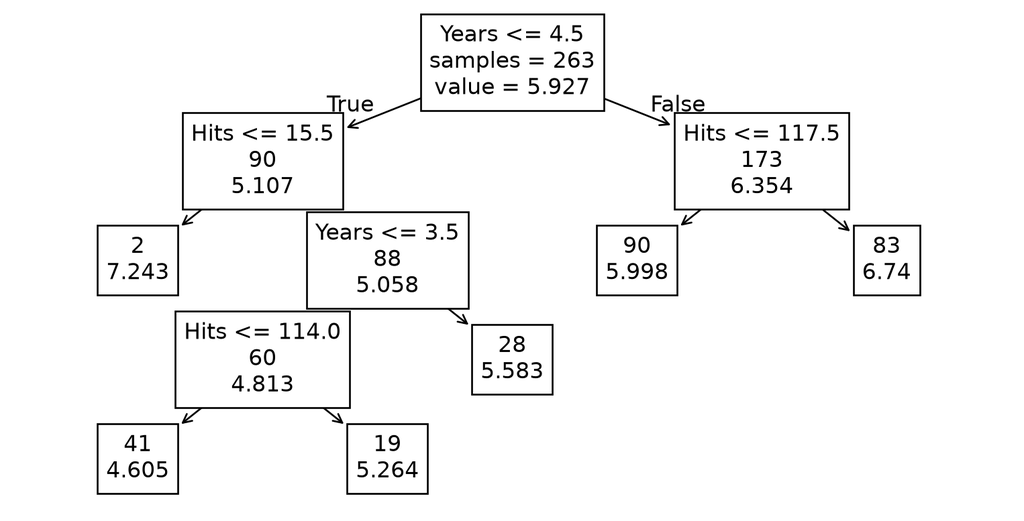

```python
plot_tree(
    grid.best_estimator_, feature_names=["Years", "Hits"], impurity=False, label="root"
)
pass
```

```python
cvs["best"] = cross_val_score(grid.best_estimator_, X, y, cv=10).mean()
cvs
```

```
{'3_depth': np.float64(0.5027641922407687),
 '5_leafs': np.float64(0.5484981677758443),
 '2_depth': np.float64(0.4930136953220773),
 'best': np.float64(0.5771947058581948)}
```

The best model is the cross-validated model because it has the highest score ($R^2$).

## Bigger model

- Data
- New data
- GridSearchCV
- Parameters
- Plot

```python
X.dtypes
```

```
Years    int64
Hits     int64
dtype: object
```

```python
X = Hitters.drop(["Salary", "LogSalary", "League", "Division", "NewLeague"], axis = 1)
y = Hitters["LogSalary"]
```

```python
ccp_alphas = np.logspace(-2, 1, 20)
grid = GridSearchCV(regressor, param_grid={"ccp_alpha": ccp_alphas}, cv=10).fit(X, y)
```

```python
grid.best_score_
```

```
np.float64(0.6745316153671909)
```

```python
grid.best_params_
```

```
{'ccp_alpha': np.float64(0.01438449888287663)}
```

```python
print(grid.best_estimator_.get_n_leaves())
print(grid.best_estimator_.get_depth())
```

```
6
3
```

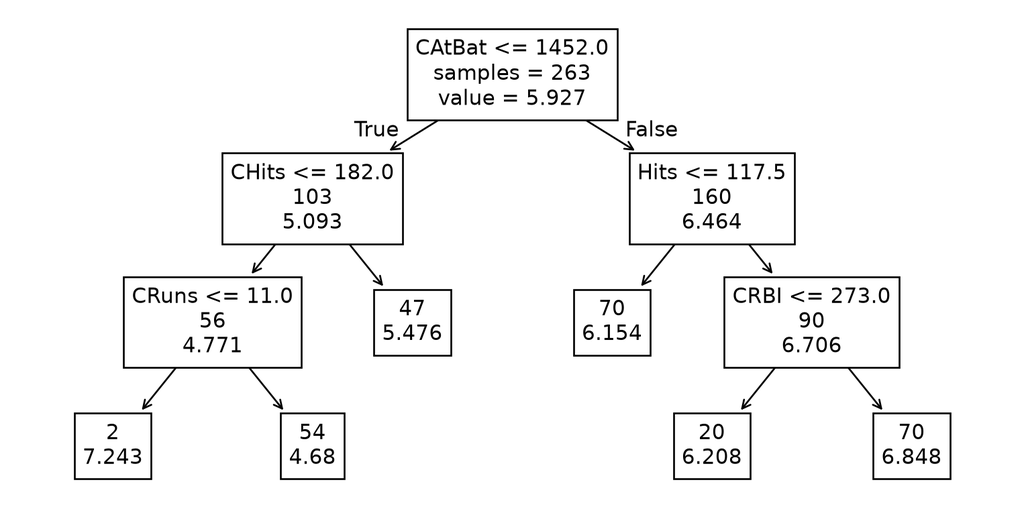

```python
plot_tree(grid.best_estimator_, feature_names = X.columns, impurity = False, label = "root")
pass
```

## Pros and cons

1. Trees are very easy to explain to people. Even easier to explain than linear regression!.
2. Trees more closely mirror human decision-making than do the regression and classification approaches we have seen.
3. Trees can be displayed graphically, and are easily interpreted even by a non-expert, especially if they are small.
- Some tree implementations can handle qualitative predictors directly. Scikit-learn’s tree estimators require numerical encoding first.
- Unfortunately, trees generally do not have the same level of predictive accuracy as some of the other regression and classification approaches seen in this book.
- However, by aggregating many decision trees, the predictive performance of trees can be substantially improved. We introduce these concepts in the next lecture.